# Lecture 2: The grammar of graphics and filtering data

To display the FGP histogram, we will simply add the `geom_histogram()` layer to the plot using the `+` operator:

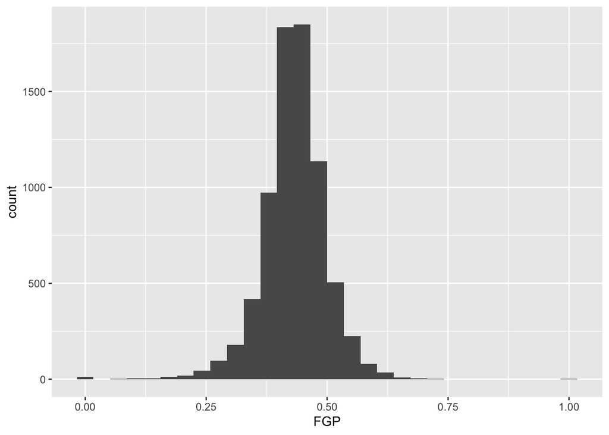

```r
ggplot(data = raw_shooting, aes(x = FGP)) +
  geom_histogram()
```

And of course, we can equivalently generate the same figure by **piping** our dataset into the `ggplot` function. The remaining examples will use the pipe operator `%>%` for the remainder of this week, emphasizing how you can manipulate the `tbl` with various other functions prior to displaying the data:

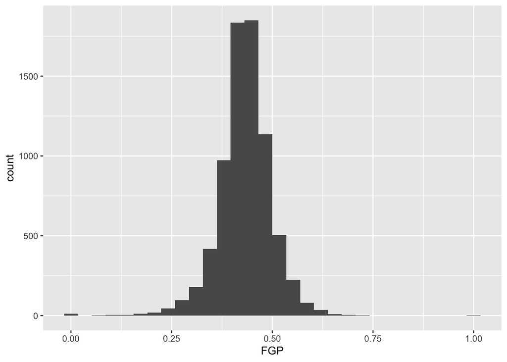

```r
raw_shooting %>%
  ggplot(aes(x = FGP)) +
  geom_histogram()
```

Each `geom` has it various attributes that can be modified whether by mapping variables with `aes` or *global* settings that affects the final displayed plot. A common problem faced with histograms is determining the width of the bins or number of bins - how much smoothing do we want of the data? You might have noticed that by default `geom_histogram` is using 30 bins and prints out a message for us about this decision. We can easily modify the number of bins in the `geom_histogram` function using the `bins` argument:

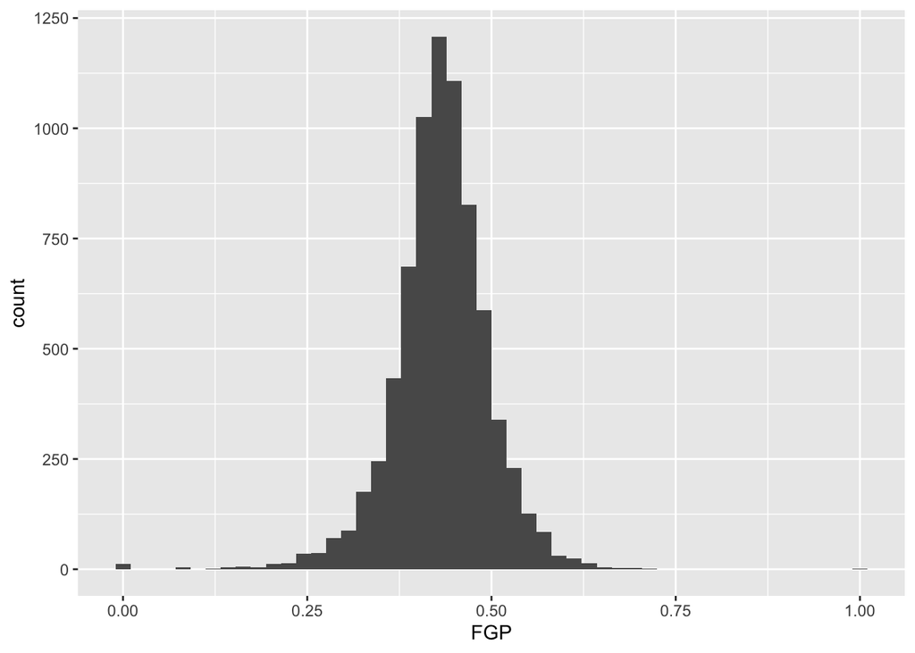

```r
raw_shooting %>%
  ggplot(aes(x = FGP)) +
  geom_histogram(bins = 50)
```

Or we directly specify the width of the bins reflecting the range of FGP included in each bin using `binwidth`:

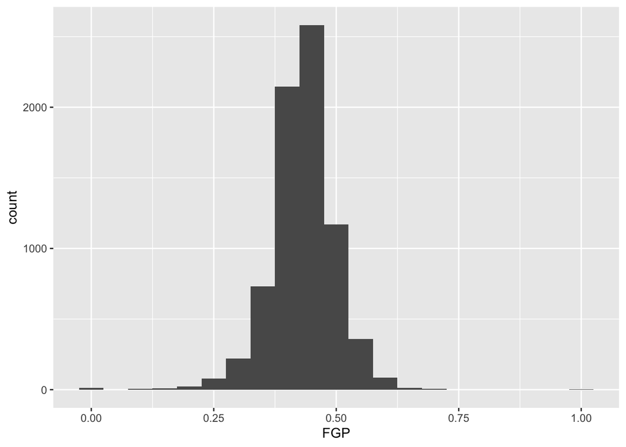

```r
raw_shooting %>%
  ggplot(aes(x = FGP)) +
  geom_histogram(binwidth = 0.05)
```

Try making histograms of `FTP`, `TPP`, and the other variables created above, and compare the shapes of the distributions.

## Filtering

By this point, it should be clear that there are a number of rather curious features in our dataset. For instance, there seem to be several players who have never made a field goal but have made every one of their free throw attempts. As it turns out, we have several players who have attempted fewer than 5 field goals in a single season. We’d like to remove all of the players who have not attempted a considerable number of field goal attempts and three point attempts in order to understand how the rate and efficiency of three point shots has changed over time.

The `filter()` function is used to pull out subsets of observations that satisfy some logical condition like `FGA > 100` or `FGA > 100` and `FTA > 50`. To make such comparisons in R, we have the following operators available at our disposal:

- `==` for “equal to”
- `!=` for “not equal to”
- `<` and `<=` for “less than” and “less than or equal to”
- `>` and `>=` for “greater than” and “greater than or equal to”
- `&`, `|`, `!` for “AND” and “OR” and “NOT”

The code below filter out all of the players with at least 100 field goals in a single season.

```r
raw_shooting %>%
  filter(FGA > 100)
```

```
## # A tibble: 6,295 × 14
##    PLAYER   SEASON   FGM   FGA   TPM   TPA   FTM   FTA     FGP     TPP     FTP    eFGP   PTS     TSP
##    <chr>     <dbl> <dbl> <dbl> <dbl> <dbl> <dbl> <dbl>   <dbl>   <dbl>   <dbl>   <dbl> <dbl>   <dbl>
##  1 Chris W…   2013   110   153     0     1    39    58 0.71895 0       0.67241 0.71895   259 0.72541
##  2 Tyson C…   2012   241   355     0     2   217   315 0.67887 0       0.68889 0.67887   699 0.70806
##  3 Kyle Ko…   2015   292   600   221   449   106   118 0.48667 0.49220 0.89831 0.67083   911 0.69871
##  4 Steve N…   2012   161   337   133   282    22    26 0.47774 0.47163 0.84615 0.67507   477 0.68448
##  5 Chris A…   2014   177   275     3    12   120   169 0.64364 0.25    0.71006 0.64909   477 0.68268
##  6 Jeremy …   2011    76   115     0     1    26    37 0.66087 0       0.70270 0.66087   178 0.67794
##  7 Carlos …   2001    75   110     0     1    29    52 0.68182 0       0.55769 0.68182   179 0.67354
##  8 Mason P…   2014   199   302     0     3   122   195 0.65894 0       0.62564 0.65894   520 0.67045
##  9 Stephen…   2016   805  1597   402   887   363   400 0.50407 0.45321 0.9075  0.62993  2375 0.66977
## 10 Brent B…   2004   215   427   114   252    91   110 0.50351 0.45238 0.82727 0.63700   635 0.66786
## # ℹ 6,285 more rows
```

When we run this code, you’ll notice that R prints out a `tbl` with 6,295 rows.

We can also filter on more complicated conditions constructed using the AND, OR, and NOT operators: `&`, `|`, and `!`. For instance, to filter observations with at least 100 field goal attempts OR 50 three point attempts, we would do

```r
raw_shooting %>%
  filter(FGA >= 100 | TPA >= 50)
```

```
## # A tibble: 6,328 × 14
##    PLAYER   SEASON   FGM   FGA   TPM   TPA   FTM   FTA     FGP     TPP     FTP    eFGP   PTS     TSP
##    <chr>     <dbl> <dbl> <dbl> <dbl> <dbl> <dbl> <dbl>   <dbl>   <dbl>   <dbl>   <dbl> <dbl>   <dbl>
##  1 Chris W…   2013   110   153     0     1    39    58 0.71895 0       0.67241 0.71895   259 0.72541
##  2 Tyson C…   2012   241   355     0     2   217   315 0.67887 0       0.68889 0.67887   699 0.70806
##  3 Kyle Ko…   2015   292   600   221   449   106   118 0.48667 0.49220 0.89831 0.67083   911 0.69871
##  4 Steve N…   2012   161   337   133   282    22    26 0.47774 0.47163 0.84615 0.67507   477 0.68448
##  5 Chris A…   2014   177   275     3    12   120   169 0.64364 0.25    0.71006 0.64909   477 0.68268
##  6 Jeremy …   2011    76   115     0     1    26    37 0.66087 0       0.70270 0.66087   178 0.67794
##  7 Carlos …   2001    75   110     0     1    29    52 0.68182 0       0.55769 0.68182   179 0.67354
##  8 Brian C…   2011    43   100    42    87    17    18 0.43    0.48276 0.94444 0.64      145 0.67179
##  9 Mason P…   2014   199   302     0     3   122   195 0.65894 0       0.62564 0.65894   520 0.67045
## 10 Stephen…   2016   805  1597   402   887   363   400 0.50407 0.45321 0.9075  0.62993  2375 0.66977
## # ℹ 6,318 more rows
```

We may combine these constraints by enclosing them in parentheses.

```r
raw_shooting %>%
  filter((FGA >= 100 & TPA >= 50) | (FGP >= 0.45 & FGP <= 0.5))
```

```
## # A tibble: 4,837 × 14
##    PLAYER   SEASON   FGM   FGA   TPM   TPA   FTM   FTA     FGP     TPP     FTP    eFGP   PTS     TSP
##    <chr>     <dbl> <dbl> <dbl> <dbl> <dbl> <dbl> <dbl>   <dbl>   <dbl>   <dbl>   <dbl> <dbl>   <dbl>
##  1 Keith B…   2014     3     6     3     6     3     3 0.5     0.5     1       0.75       12 0.81967
##  2 Kyle Ko…   2015   292   600   221   449   106   118 0.48667 0.49220 0.89831 0.67083   911 0.69871
##  3 Aleksan…   1997     8    16     5     7     4     5 0.5     0.71429 0.8     0.65625    25 0.68681
##  4 Steve N…   2012   161   337   133   282    22    26 0.47774 0.47163 0.84615 0.67507   477 0.68448
##  5 Brian C…   2011    43   100    42    87    17    18 0.43    0.48276 0.94444 0.64      145 0.67179
##  6 Stephen…   2016   805  1597   402   887   363   400 0.50407 0.45321 0.9075  0.62993  2375 0.66977
##  7 Brent B…   2004   215   427   114   252    91   110 0.50351 0.45238 0.82727 0.63700   635 0.66786
##  8 Manu Gi…   2012   150   285    52   126    88   101 0.52632 0.41270 0.87129 0.61754   440 0.66780
##  9 Steve K…   1997   249   467   110   237    54    67 0.53319 0.46414 0.80597 0.65096   662 0.66669
## 10 Brent B…   2007   202   425   128   287   103   117 0.47529 0.44599 0.88034 0.62588   635 0.66634
## # ℹ 4,827 more rows
```

What if we wanted to pull out the observations corresponding to the 2015-16 and 2014-15 season? We could do something like `filter(raw_shooting, (SEASON == 2016) | (SEASON == 2015))`, which would be perfectly fine. However, what if we wanted data from 1998-99, 2011-12, and 2015-16? Typing a lot of expressions like `SEASON == ...` would be rather tedious. The `%in%` operator lets us avoid this tedium:

```r
raw_shooting %>%
  filter(SEASON %in% c(1999, 2012, 2016))
```

```
## # A tibble: 1,150 × 14
##    PLAYER   SEASON   FGM   FGA   TPM   TPA   FTM   FTA     FGP     TPP     FTP    eFGP   PTS     TSP
##    <chr>     <dbl> <dbl> <dbl> <dbl> <dbl> <dbl> <dbl>   <dbl>   <dbl>   <dbl>   <dbl> <dbl>   <dbl>
##  1 Tyson W…   1999     1     1     1     1     1     2 1       1       0.5     1.5         4 1.0638
##  2 Tyson C…   2012   241   355     0     2   217   315 0.67887 0       0.68889 0.67887   699 0.70806
##  3 Jorge G…   2016     6    11     0     2    10    11 0.54545 0       0.90909 0.54545    22 0.69444
##  4 Steve N…   2012   161   337   133   282    22    26 0.47774 0.47163 0.84615 0.67507   477 0.68448
##  5 Sam Jac…   1999     3     5     0     1     2     2 0.6     0       1       0.6         8 0.68027
##  6 Stephen…   2016   805  1597   402   887   363   400 0.50407 0.45321 0.9075  0.62993  2375 0.66977
##  7 Manu Gi…   2012   150   285    52   126    88   101 0.52632 0.41270 0.87129 0.61754   440 0.66780
##  8 James H…   2012   309   629   114   292   312   369 0.49126 0.39041 0.84553 0.58188  1044 0.65962
##  9 Steve N…   2016     8    18     7    15     1     1 0.44444 0.46667 1       0.63889    24 0.65076
## 10 Brad Mi…   1999    78   138     1     2    81   102 0.56522 0.5     0.79412 0.56884   238 0.65070
## # ℹ 1,140 more rows
```

We could also filter out data from the two lockout-shortened seasons, 1998-99 and 2011-12 using a combination of the NOT `!` operator and `%in%`.

```r
raw_shooting %>%
  filter(!SEASON %in% c(1999, 2012))
```

```
## # A tibble: 6,721 × 14
##    PLAYER   SEASON   FGM   FGA   TPM   TPA   FTM   FTA     FGP     TPP     FTP    eFGP   PTS     TSP
##    <chr>     <dbl> <dbl> <dbl> <dbl> <dbl> <dbl> <dbl>   <dbl>   <dbl>   <dbl>   <dbl> <dbl>   <dbl>
##  1 Dajuan …   2007     1     1     1     1     1     2 1       1       0.5     1.5         4 1.0638
##  2 Amir Jo…   2006     7    10     2     3     4     4 0.7     0.66667 1       0.8        20 0.85034
##  3 Keith B…   2014     3     6     3     6     3     3 0.5     0.5     1       0.75       12 0.81967
##  4 Steve N…   2011    35    67    26    46     8     8 0.52239 0.56522 1       0.71642   104 0.73738
##  5 Chris C…   2003     8    13     1     3     7     8 0.61538 0.33333 0.875   0.65385    24 0.72639
##  6 Chris W…   2013   110   153     0     1    39    58 0.71895 0       0.67241 0.71895   259 0.72541
##  7 Maceo B…   2007    49    76     3     7    37    47 0.64474 0.42857 0.78723 0.66447   138 0.71369
##  8 Kyle Ko…   2015   292   600   221   449   106   118 0.48667 0.49220 0.89831 0.67083   911 0.69871
##  9 Jorge G…   2016     6    11     0     2    10    11 0.54545 0       0.90909 0.54545    22 0.69444
## 10 Aleksan…   1997     8    16     5     7     4     5 0.5     0.71429 0.8     0.65625    25 0.68681
## # ℹ 6,711 more rows
```

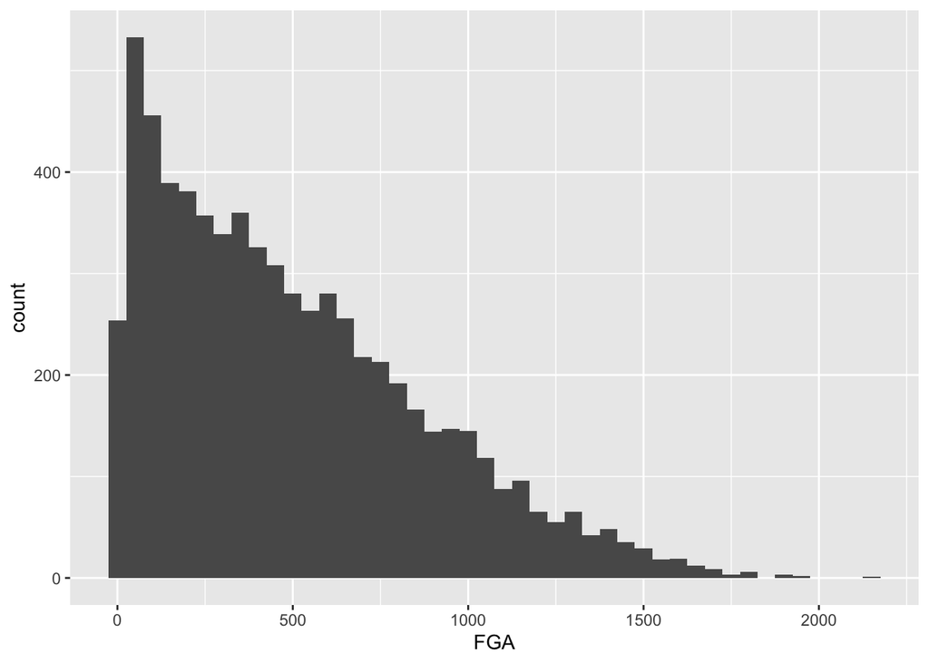

```r
raw_shooting %>%
  filter(!SEASON %in% c(1999, 2012)) %>%
  ggplot(aes(x = FGA)) +
  geom_histogram(binwidth = 50)
```

And now for TPA:

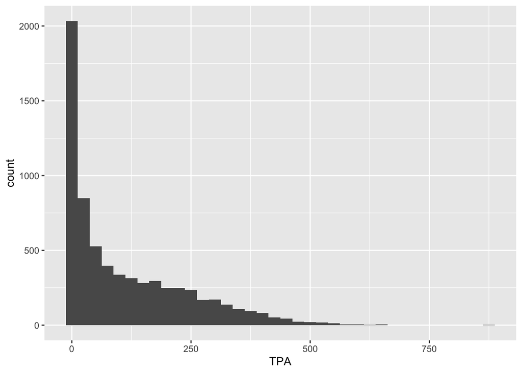

```r
raw_shooting %>%
  filter(!SEASON %in% c(1999, 2012)) %>%
  ggplot(aes(x = TPA)) +
  geom_histogram(binwidth = 25)
```

It might not make sense however to make a cutoff for FGA and TPA without considering their relationship.

## Bivariate plots for continuous data

We can proceed to view the **joint** distribution of FGA and TPA, the relationship between the two variables, by displaying a scatterplot of the data. Obviously, as TPA increases the FGA will increase (since FGA is the sum of TPA and number of two-point attempts). We create a scatterplot by mapping multiple variables to `x` and `y`, and use `geom_point` to display the desired geometric object of points instead of `geom_histogram` from before.

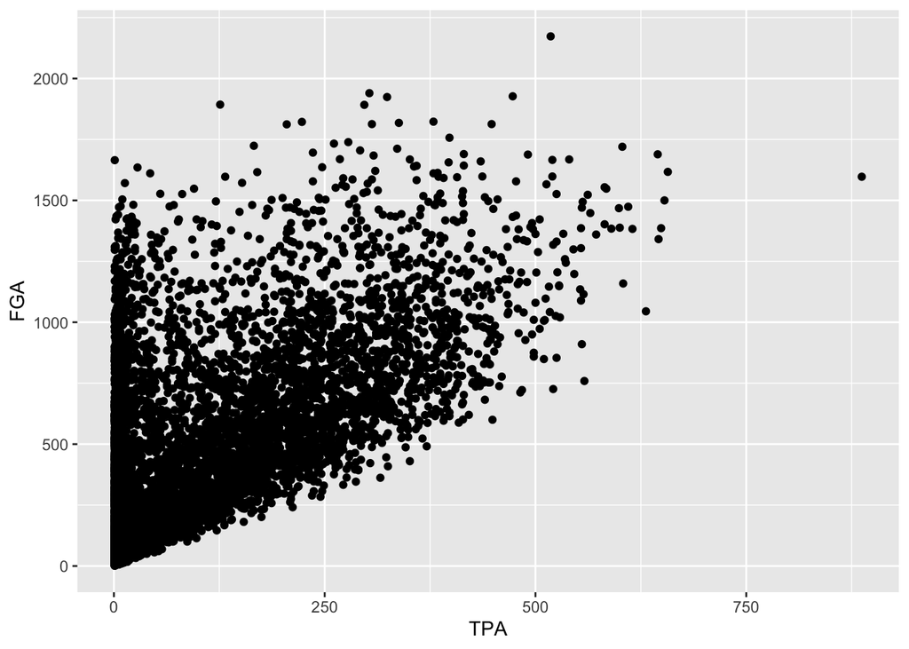

```r
raw_shooting %>%
  filter(!SEASON %in% c(1999, 2012)) %>%
  ggplot(aes(x = TPA, y = FGA)) +
  geom_point()
```

Immediately, we notice a few things about the figure. First, we see the clear relationship between TPA and FGA - where where TPA provides the lower threshold on FGA (remember why is this expected). We also see what appears to be a group of points with a smaller number of three-point attempts displaying a range in values for FGA, while a main block of points shows an clear increasing relationship. A major drawback of this scatterplot is its inability to show the relative density of points. For instance, all we see is a solid black mass for the lower range of values for both TPA and FGA - making it hard to determine where an appropriate cutoff should be made.

One way to address this is to use *alpha-blending* to change the transparency of each point. When there are many points plotted in the same region, that region will appear darker. Just like `binwidth` or `bins` for `geom_histogram`, `geom_point` has settings we can change such as the `alpha` setting in this case which ranges from 0 (completely transparent) to 1 (solid and opaque, the default).

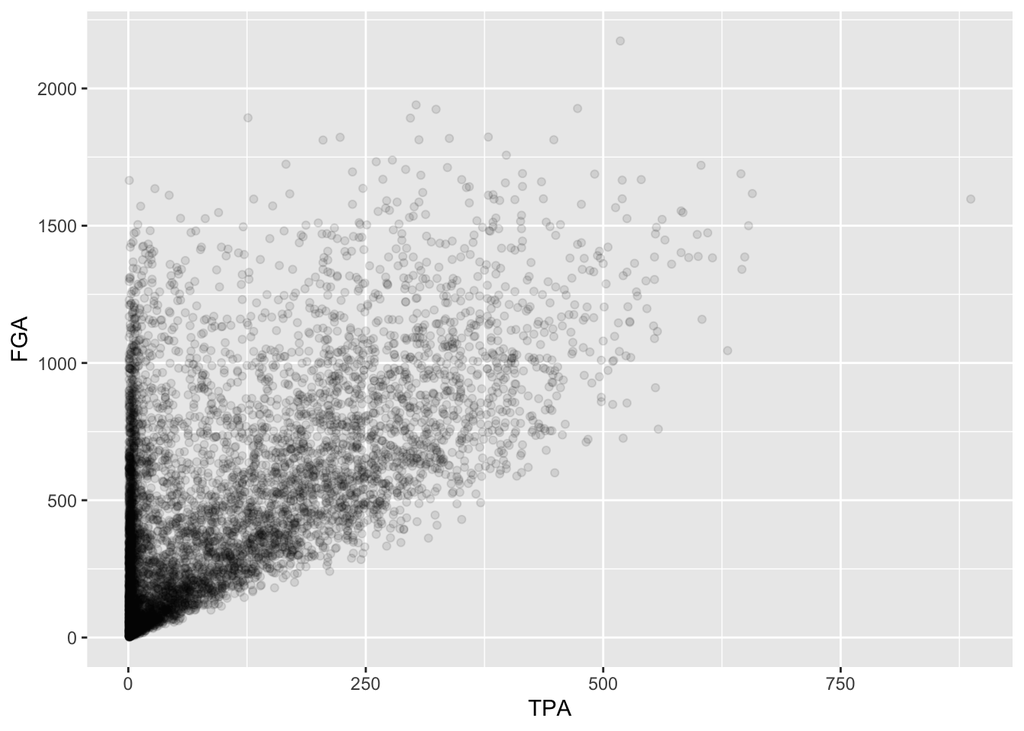

```r
raw_shooting %>%
  filter(!SEASON %in% c(1999, 2012)) %>%
  ggplot(aes(x = TPA, y = FGA)) +
  geom_point(alpha = 0.1)
```

Now we have a much better idea of where the majority of points are, with a clear group of players displaying a smaller number of TPA. Another type of plot commonly used in this situation is a **heatmap** which you can thnk of as a two-dimensional histogram. To form a heatmap, you start by dividing the coordinate plane into many evenly-sized two-dimensional bins and then count the number of points within each bin. You then color the bin according to the count. While you can conceptually make the bins any shape you want, there are two popular conventions: rectangular binning and hexagonal binning. For this plot, we will focus on rectangular binning, using the `geom_bin2d()` function.

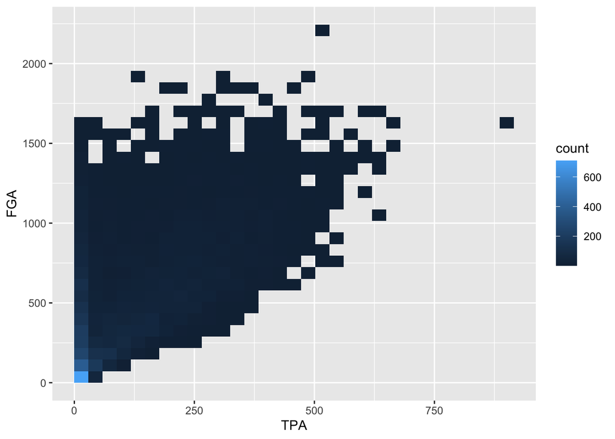

```r
raw_shooting %>%
  filter(!SEASON %in% c(1999, 2012)) %>%
  ggplot(aes(x = TPA, y = FGA)) +
  geom_bin2d()
```

Now we have a color scale that has appeared to tell us the number of points in each bin. Just like histograms, we can increase the number of bins to get a much more high-resolution view of our data.

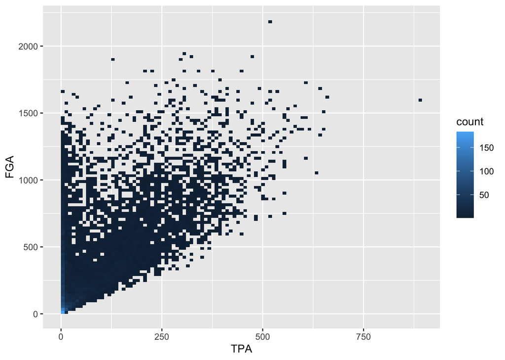

```r
raw_shooting %>%
  filter(!SEASON %in% c(1999, 2012)) %>%
  ggplot(aes(x = TPA, y = FGA)) +
  geom_bin2d(bins = 100)
```

In this example, using `geom_point` with lower values for `alpha` provides a clear interpretation for where to make the cutoff. Given the histograms we previously made for each variable as well, let’s use a cutoff of `TPA > 50` and `FGA > 150`. We can create the scatterplot as before but, to demonstrate a convenient feature of `ggplot2`, we’ll now assign the plot to a variable named `fga_tpa_plot`,

```r
fga_tpa_plot <- raw_shooting %>%
  filter(!SEASON %in% c(1999, 2012)) %>%
  ggplot(aes(x = TPA, y = FGA)) +
  geom_point(alpha = 0.1)
```

Notice how this code runs without displaying the plot. To display it we simplyrun `fga_tpa_plot` in the console and the plot appear,

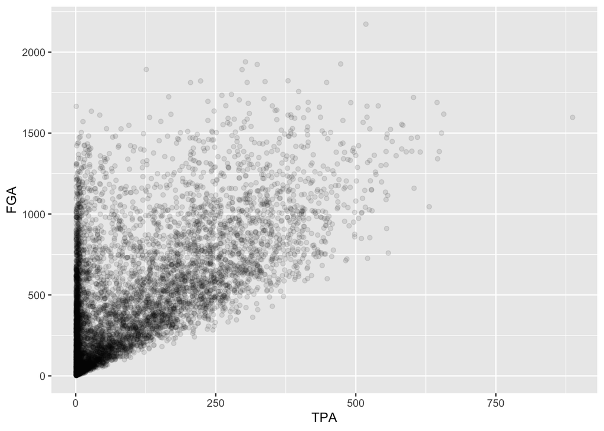

```r
fga_tpa_plot
```

Now we’re going to annotate this plot with the cutoffs we’ve determined. To do so, we’re going to add a vertical line to provide the cutoff for the minimum value of TPA, and a horizontal line for the minimum value of FGA. Both of these can be accomplished using the `geom`s `geom_vline` and `geom_hline` where we specify for each the values for the intercepts to draw the lines at. Since we’ve stored the plot in `fga_tpa_plot`, we can add these layers with the `+` operator to `fga_tpa_plot` directly:

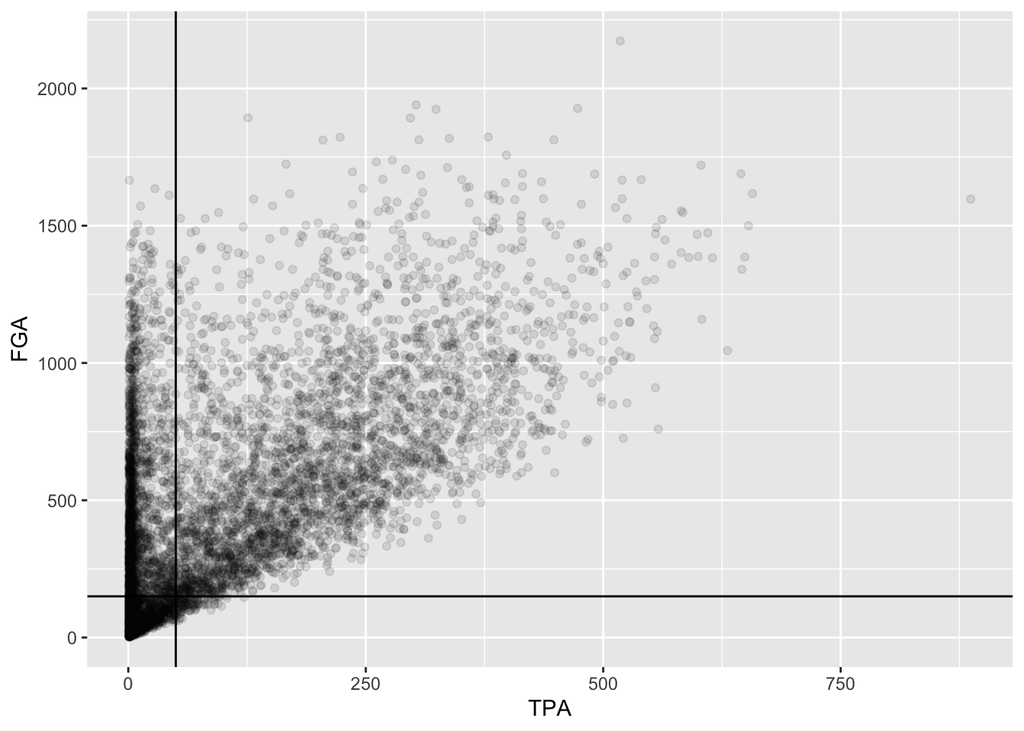

```r
fga_tpa_plot +
  # Add TPA cutoff
  geom_vline(xintercept = 50) +
  # Add FGA cutoff
  geom_hline(yintercept = 150)
```

This provides us with a good indication of what we’re cutting off, but we should distinguish these lines separately from the points more. Since these are both `geom`s with their own set of attributes, we’ll change the color and make the line type to be dashed,

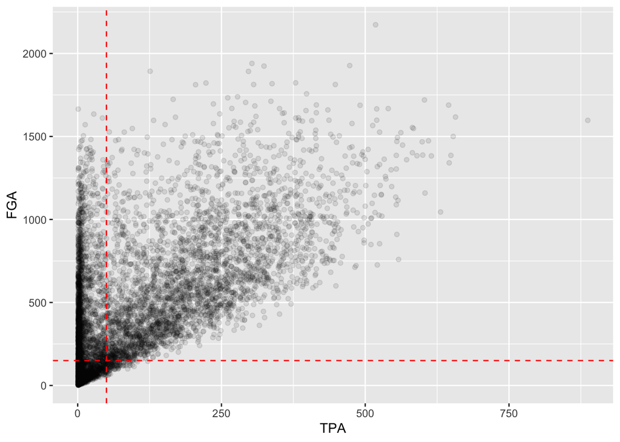

```r
fga_tpa_plot +
  # Add TPA cutoff
  geom_vline(xintercept = 50, color = "red", linetype = "dashed") +
  # Add FGA cutoff
  geom_hline(yintercept = 150, color = "red", linetype = "dashed")
```

Although `ggplot2` automatically provides axis labels based on the variables we’ve mapped to the aesthetics in `aes`, we really need text describing what is shown in the plot. The easiest way to do this, is by adding a label layer with the `labs()` function. Using `labs`, you can provide it the same arguments as those inside `aes` as well as other parts of the plot to label such as the title, subtitle, and caption. We add appropriate labels to the plot above, with better descriptions for the axes, as well as an informative subtitle regarding the red-dashed lines:

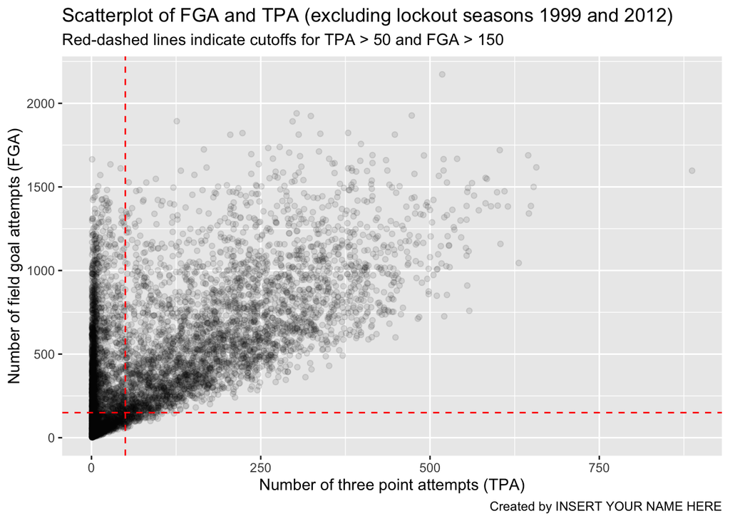

```r
fga_tpa_plot +
  # Add TPA cutoff
  geom_vline(xintercept = 50, color = "red", linetype = "dashed") +
  # Add FGA cutoff
  geom_hline(yintercept = 150, color = "red", linetype = "dashed") +
  # Add appropriate labels:
  labs(x = "Number of three point attempts (TPA)",
       y = "Number of field goal attempts (FGA)",
       title = "Scatterplot of FGA and TPA (excluding lockout seasons 1999 and 2012)",
       subtitle = "Red-dashed lines indicate cutoffs for TPA > 50 and FGA > 150",
       caption = "Created by INSERT YOUR NAME HERE")
```

As a reminder, the code chunk above is equivalent to running the entire pipeline of code without creating any temporary objects, although not recommended…

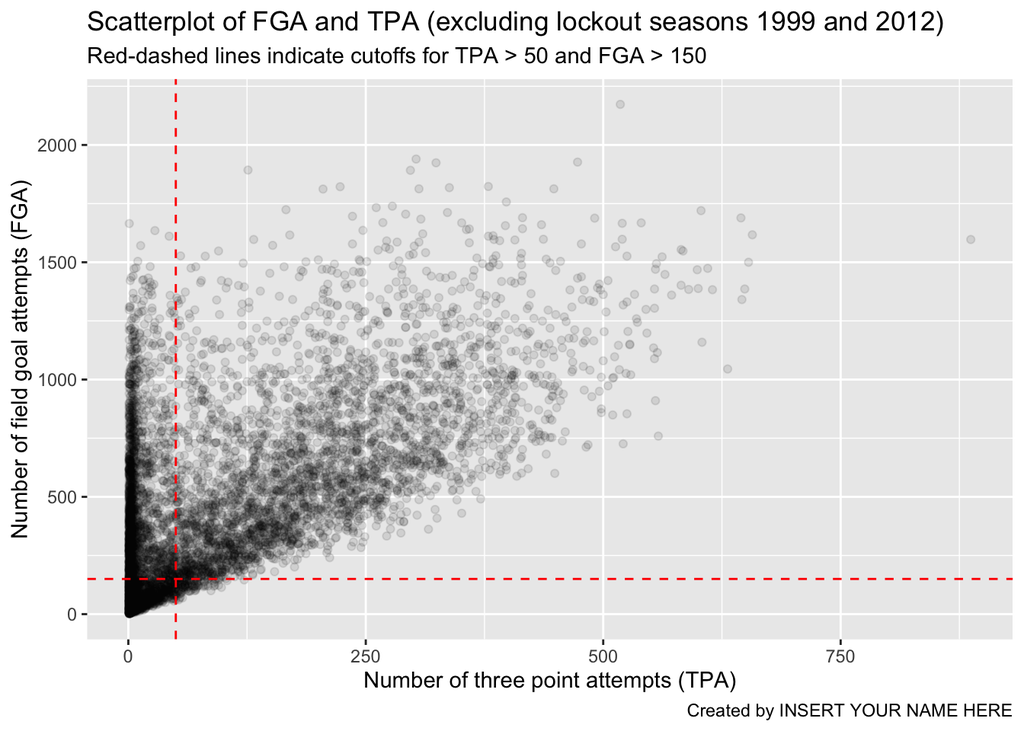

```r
read_csv(file = "data/nba_shooting.csv") %>%
  filter(!SEASON %in% c(1999, 2012)) %>%
  ggplot(aes(x = TPA, y = FGA)) +
  geom_point(alpha = 0.1) +
  geom_vline(xintercept = 50, color = "red", linetype = "dashed") +
  geom_hline(yintercept = 150, color = "red", linetype = "dashed") +
  labs(x = "Number of three point attempts (TPA)",
       y = "Number of field goal attempts (FGA)",
       title = "Scatterplot of FGA and TPA (excluding lockout seasons 1999 and 2012)",
       subtitle = "Red-dashed lines indicate cutoffs for TPA > 50 and FGA > 150",
       caption = "Created by INSERT YOUR NAME HERE")
```

## Saving our work

For the next lecture we will focus on the dataset of players who attempted at least 150 field goals and 50 three pointers in the non-lockout seasons. We’ll make this *clean* dataset using the `filter()` function separating each condition with commas, and refer to the resulting dataset as `nba_shooting`. Finally, we’ll add a `mutate()` line to create the `three_point_fg_rate = TPA / FGA` variable from yesterday.

```r
nba_shooting <- raw_shooting %>%
  # Filter on the conditions
  filter(!SEASON %in% c(1999, 2012),
         TPA > 50,
         FGA > 150) %>%
  # Create the three point attempt rate variable
  mutate(three_point_fg_rate = TPA / FGA)
```

While we can always re-run the commands used to produce this `tbl` from our script, when data analyses become more complicated, it is helpful to save these objects. `R` has its own special file format for efficiently saving data on your computer.

We will use the `save()` command.

```r
save(nba_shooting, file = "data/clean_nba_shooting.RData")
```

Then when we want to *load* the data back into R, we can use the `load()` function.

```r
load("data/clean_nba_shooting.RData")
```

Next, proceed to practice this lecture’s lessons in Problem Set 2.